# Reproducible Research: Peer Assessment 2

Usama Bin Rahat

8/27/2021

# Weather Events: Health and Economic impacts

## Synopsis

The objective of this report is to study and analyze weather events, which are most harmful in terms of health as well as economic impacts. To conduct our analysis, the dataset has been taken from the U.S. National Oceanic and Atmospheric Administration’s (NOAA) storm database. In our study, the whole data was used without filtering for no. of years or specific dates.

## Data Processing

In this section, the process for downloading the data, loading it into the R environment, and processing steps before the analysis are explained.

### Downloading the data

Data from the U.S. National Oceanic and Atmospheric Administration’s (NOAA) storm database was downloaded using the url provided into the required parent directory. Data downloaded was in the .bz2 format.

```r
fileUrl <- "https://d396qusza40orc.cloudfront.net/repdata%2Fdata%2FStormData.csv.bz2"
fileDest <- "repdata_data_StormData.csv.bz2"

download.file(url = fileUrl,
              destfile = fileDest,
              method = "curl")
```

### Reading the data

Once the data was downloaded, it was read into the R environment.

```r
full_data <- read.csv("repdata_data_StormData.csv.bz2")
str(full_data)
```

```
## 'data.frame':    902297 obs. of  37 variables:
##  $ STATE__   : num  1 1 1 1 1 1 1 1 1 1 ...
##  $ BGN_DATE  : chr  "4/18/1950 0:00:00" "4/18/1950 0:00:00" "2/20/1951 0:00:00" "6/8/1951 0:00:00" ...
##  $ BGN_TIME  : chr  "0130" "0145" "1600" "0900" ...
##  $ TIME_ZONE : chr  "CST" "CST" "CST" "CST" ...
##  $ COUNTY    : num  97 3 57 89 43 77 9 123 125 57 ...
##  $ COUNTYNAME: chr  "MOBILE" "BALDWIN" "FAYETTE" "MADISON" ...
##  $ STATE     : chr  "AL" "AL" "AL" "AL" ...
##  $ EVTYPE    : chr  "TORNADO" "TORNADO" "TORNADO" "TORNADO" ...
##  $ BGN_RANGE : num  0 0 0 0 0 0 0 0 0 0 ...
##  $ BGN_AZI   : chr  "" "" "" "" ...
##  $ BGN_LOCATI: chr  "" "" "" "" ...
##  $ END_DATE  : chr  "" "" "" "" ...
##  $ END_TIME  : chr  "" "" "" "" ...
##  $ COUNTY_END: num  0 0 0 0 0 0 0 0 0 0 ...
```

[output cut: 23 more lines]

### Processing the data

To process the data, we first load the required libraries in our working environment.

```r
library(tidyverse)
library(ggplot2)
library(reshape2)
```

From the variables present in the data, we only require those which are required for our analysis. The impact of weather types on health can be determined from fatalities and injuries. The economic impact can be estimated by taking into account the property damage and the crops damage. Therefore, only the variables related to these are selected from the dataset.

```r
trimmed_data <- full_data %>%
  select(EVTYPE,
         FATALITIES,
         INJURIES,
         CROPDMG,
         CROPDMGEXP,
         PROPDMG,
         PROPDMGEXP)
```

The first step is to determine the event types. The no. of events in our case are 985, as shown below.

```r
length(unique(trimmed_data$EVTYPE))
```

```
## [1] 985
```

```r
trimmed_data <- trimmed_data %>%
  mutate(HEALTH_METRIC = FATALITIES + INJURIES)

head(trimmed_data)
```

```
##    EVTYPE FATALITIES INJURIES CROPDMG CROPDMGEXP PROPDMG PROPDMGEXP
## 1 TORNADO          0       15       0               25.0          K
## 2 TORNADO          0        0       0                2.5          K
## 3 TORNADO          0        2       0               25.0          K
## 4 TORNADO          0        2       0                2.5          K
## 5 TORNADO          0        2       0                2.5          K
## 6 TORNADO          0        6       0                2.5          K
##   HEALTH_METRIC
## 1            15
## 2             0
## 3             2
## 4             2
## 5             2
## 6             6
```

The next step is to convert the crop damage and property damage according to their exponents. To do that, we will use the exponent variables and convert the data

```r
trimmed_data <- trimmed_data %>%
  mutate(PROPDMG = case_when(
    PROPDMGEXP == 'K' ~ PROPDMG*10^3,
    PROPDMGEXP == '2' ~ PROPDMG*10^2,
    PROPDMGEXP == 'M' ~ PROPDMG*10^6,
    PROPDMGEXP == 'B' ~ PROPDMG*10^9,
    TRUE ~ PROPDMG),
         CROPDMG = case_when(
    CROPDMGEXP == '1' ~ CROPDMG*10^1,
    CROPDMGEXP == '2' ~ CROPDMG*10^2,
    CROPDMGEXP == 'K' | CROPDMGEXP == '3' ~ CROPDMG*10^3,
    CROPDMGEXP == '4' ~ CROPDMG*10^4,
    CROPDMGEXP == '5' ~ CROPDMG*10^5,
    CROPDMGEXP == 'M' | CROPDMGEXP == '6' ~ CROPDMG*10^6,
    CROPDMGEXP == '7' ~ CROPDMG*10^7,
    CROPDMGEXP == '8' ~ CROPDMG*10^8,
    CROPDMGEXP == 'B' | CROPDMGEXP == '9' ~ CROPDMG*10^9,
    TRUE ~ CROPDMG)
        )

head(trimmed_data)
```

```
##    EVTYPE FATALITIES INJURIES CROPDMG CROPDMGEXP PROPDMG PROPDMGEXP
## 1 TORNADO          0       15       0              25000          K
## 2 TORNADO          0        0       0               2500          K
## 3 TORNADO          0        2       0              25000          K
## 4 TORNADO          0        2       0               2500          K
## 5 TORNADO          0        2       0               2500          K
## 6 TORNADO          0        6       0               2500          K
##   HEALTH_METRIC
## 1            15
## 2             0
## 3             2
## 4             2
## 5             2
## 6             6
```

After transforming the data, we add the crop damage and property damage to create our metric for economic damage comparison.

```r
trimmed_data <- trimmed_data %>%
  mutate(ECON_METRIC = PROPDMG + CROPDMG)

head(trimmed_data)
```

```
##    EVTYPE FATALITIES INJURIES CROPDMG CROPDMGEXP PROPDMG PROPDMGEXP
## 1 TORNADO          0       15       0              25000          K
## 2 TORNADO          0        0       0               2500          K
## 3 TORNADO          0        2       0              25000          K
## 4 TORNADO          0        2       0               2500          K
## 5 TORNADO          0        2       0               2500          K
## 6 TORNADO          0        6       0               2500          K
##   HEALTH_METRIC ECON_METRIC
## 1            15       25000
## 2             0        2500
## 3             2       25000
## 4             2        2500
## 5             2        2500
## 6             6        2500
```

Finally, we group our data by event type, and summarize by the sum of the both our metrics.

```r
final_data <- trimmed_data %>%
  group_by(EVTYPE) %>%
  summarise(HEALTH_METRIC = sum(HEALTH_METRIC),
            FATALITIES = sum(FATALITIES),
            INJURIES = sum(INJURIES),
            ECON_METRIC = sum(ECON_METRIC),
            CROPDMG = sum(CROPDMG),
            PROPDMG = sum(PROPDMG)) %>%
  arrange(desc(HEALTH_METRIC),
          desc(ECON_METRIC))

head(final_data)
```

```
## # A tibble: 6 x 7
##   EVTYPE         HEALTH_METRIC FATALITIES INJURIES  ECON_METRIC CROPDMG  PROPDMG
##   <chr>                  <dbl>      <dbl>    <dbl>        <dbl>   <dbl>    <dbl>
## 1 TORNADO                96979       5633    91346      5.73e10  4.15e8  5.69e10
## 2 EXCESSIVE HEAT          8428       1903     6525      5.00e 8  4.92e8  7.75e 6
## 3 TSTM WIND               7461        504     6957      5.04e 9  5.54e8  4.48e 9
## 4 FLOOD                   7259        470     6789      1.50e11  5.66e9  1.45e11
## 5 LIGHTNING               6046        816     5230      9.41e 8  1.21e7  9.29e 8
## 6 HEAT                    3037        937     2100      4.03e 8  4.01e8  1.80e 6
```

The above data is prepared for our analysis.

## Results

In this section, we will find the weather event types which are most harmful in terms of health and in terms of economics.

### Health Metrics

To do that, we first sort our data by our health metric in descending order and chose the top 10 values required for the analysis. We then melt the data for the visual representation.

```r
health_data <- final_data %>%
  arrange(desc(HEALTH_METRIC)) %>%
  slice(1:10) %>%
  select(EVTYPE,
         FATALITIES,
         INJURIES) %>%
  melt(id.vars = "EVTYPE",
       variable.name = "Type")
```

The next step is to plot our stacked chart.

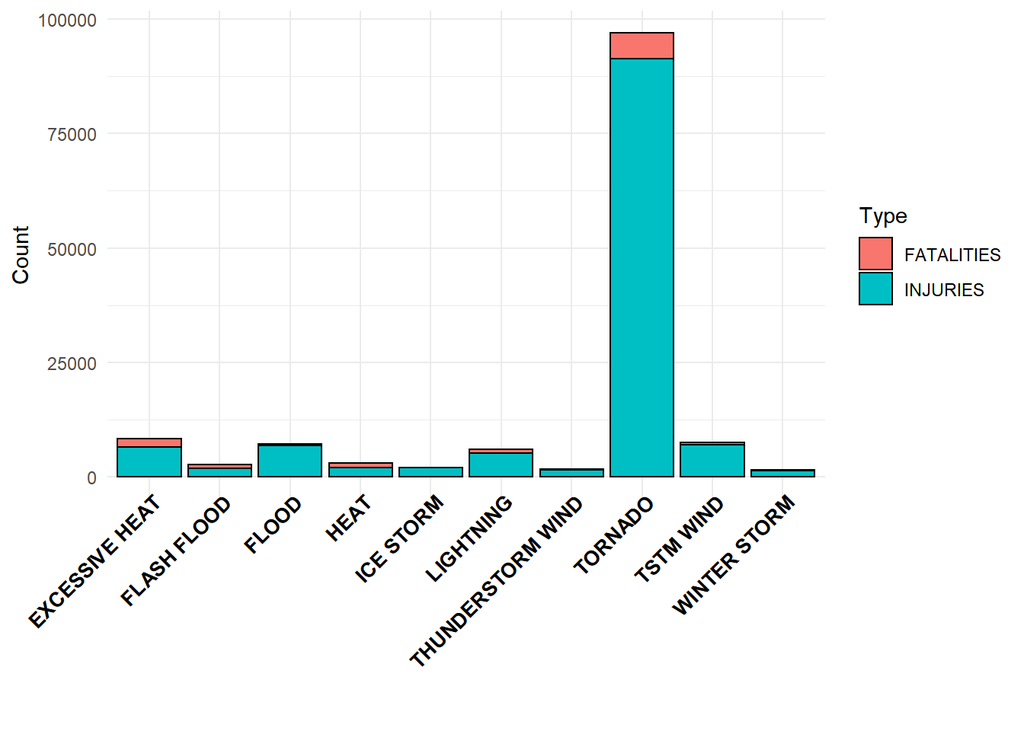

```r
ggplot(health_data,
       aes(x = EVTYPE,
           fill = Type,
           y = value)) +
  geom_bar(stat = "identity",
           colour = "black") +
  theme_minimal() +
  theme(axis.text.x = element_text(angle = 45,
                                   size = 10,
                                   colour = "black",
                                   vjust = 1.1,
                                   hjust = 1,
                                   face= "bold")) +
  xlab("") +
  ylab("Count")
```

From the plot, we can clearly see that the most harmful event type of weather phenomenon in terms of harmfulness to health is Tornado.

### Economic Metrics

Similar to the above task, we sort our data by our economics metric in descending order and chose the top 10 values required for the analysis. We then melt the data for the visual representation.

```r
econ_data <- final_data %>%
  arrange(desc(ECON_METRIC)) %>%
  slice(1:10) %>%
  select(EVTYPE,
         PROPDMG,
         CROPDMG) %>%
  melt(id.vars = "EVTYPE", variable.name = "Type")
```

The next step is to plot our stacked chart.

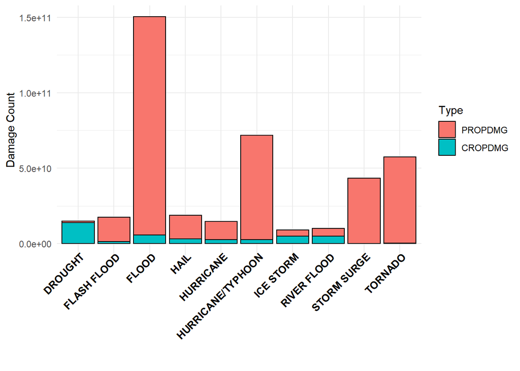

```r
ggplot(econ_data,
       aes(x = EVTYPE,
           fill = Type,
           y = value)) +
  geom_bar(stat = "identity",
           colour = "black") +
  theme_minimal() +
  theme(axis.text.x = element_text(angle = 45,
                                   size = 10,
                                   colour = "black",
                                   vjust = 1.1,
                                   hjust = 1,
                                   face= "bold")) +
  xlab("") +
  ylab("Damage Count")
```

The plot shows that the most economically harmful weather phenomenon, is flooding.